# How to use IRTnorm

Hannah M. Heister, Casper J. Albers and Marieke E. Timmerman

2026-07-06

# Introduction

Norm-referenced psychological tests evaluate an individual’s performance relative to a reference population, typically using standardized scores such as T-, IQ- or z-scores. Many developmental and intelligence tests rely on reference populations that change continuously with age.

In such settings, item response theory (IRT)-based continuous norming models are useful for deriving age-specific norm information. These models explicitly allow the latent trait distribution to depend on age. As a result, each individual’s latent trait estimate can be directly compared to the age-specific reference population using a z-standardized norm score. As in most parametric IRT models, the latent trait distribution is assumed to be normally distributed in the reference population. Therefore, the age-related changes can be captured by modeling the distribution’s mean and standard deviation as a smooth function of age either using polynomial regression or penalized splines.

Simulation studies have demonstrated that IRT-based continuous norming models can fit empirical data well and accurately recover age-specific norms. Compared to raw score–based continuous norming methods, the default approach in many applications, IRT-based models offer several advantages. These include the use of all available item-level information, the ability to model multiple latent traits and their relationships, and the straightforward integration of adaptive testing procedures.

`IRTnorm` provides a framework for deriving age-specific norm scores using Bayesian IRT-based continuous norming models. It includes tools for model comparison, model estimation, visual inspection of model fit, and extraction of norm scores.

This vignette introduces the main modeling concepts and demonstrates the use of IRTnorm on example data.

# Workflow overview

The main workflow in `IRTnorm` consists of:

1. Select best IRTnorm model (`compare_IRTnorm_models`,`compare_polynomial_degrees`, `visual_polynomial_degrees`)
2. Fit the selected IRTnorm model and extract all important model information (`estimate_norming_model`)
3. Evaluate model fit (`NC`, `NC_visual`, `normscore_dist`, `quantile_curves`, `item_person_fit`, `effect_age`)
4. Norm new individuals using the chosen IRT-norm model (`norm_new_individual`)

# Norming a single test using 2PL-norm

We illustrate the modeling process using simulated data (response_data) to keep the example concise. In practical applications, larger data sets may be required.

The following code loads the required packages and the example data.

```r
library(IRTnorm)
library(bayesplot)
data("response_data")
```

## Perform model comparison

Selecting an appropriate IRT-based norming model requires considering a set of plausible models. This set can differ in both the IRT model choice and the model specifications for the age effects.

When selecting candidate IRT models, a pre-selection should be made based on the characteristics of the test. For example, if the test contains binary items and guessing might influence responses, a 3PL-norm model may be evaluated alongside the 2PL-norm model. If guessing is unlikely, only 1PL- and 2PL-norm models need to be considered.

To compare the fit of the plausible IRT models, the function `compare_IRTnorm_models` can be used. This functions fits the set of plausible models and returns their expected log predictive density (ELPD) differences for comparison, relying heavily on the `loo` package, see Vehtari A, Gabry J, Magnusson M, Yao Y, Bürkner P, Paananen T, Gelman A (2026). “loo: Efficient leave-one-out cross-validation and WAIC for Bayesian models.” R package version 2.10.0, https://mc-stan.org/loo/.

The IRT models to compare are indicated via `model_specifications`. This expects a list in which each element holds the model information for one norming model. Each element is itself a list containing, at minimum, `irt_model`, which indicates which IRT model should be fitted, and `age_model`, which indicates whether splines or polynomial regression should be used to model the age effects. Depending on whether splines or polynomials are selected, additional configuration options are available; see the documentation for details.

To keep the comparison fair and simple, we recommend selecting the same polynomial degrees for all models and setting them relatively high, so that they can be expected to sufficiently capture the true trajectory. Here we choose the fourth-degree polynomial for the mean and the third-degree polynomial for the standard deviation.

Finally, the norming data set must be provided as either a `data.frame` or `matrix`, containing individuals’ ages and item responses. The age variable (`age_variable`) and the item response variables (`int_variables`) must each be indicated by either their position or their variable name.

```r
 model_list <- list( A = list(irt_model = "1PLnorm", age_model = "poly",
                                        poly_mean = 4, poly_sd = 3),
                     B = list(irt_model = "2PLnorm", age_model = "poly",
                                        poly_mean = 4, poly_sd = 3))

compare_IRTnorm_models(model_specifications = model_list,
                                              raw_data = response_data,
                                              age_variable = "age",
                                              int_variables = 1:50)
```

```
#>        ELPD irt_model age_model poly_mean poly_sd modelcombi ELPD_diff       SE
#> 2 -11018.08   2PLnorm      poly         4       3        4_3    0.0000  0.00000
#> 1 -11142.35   1PLnorm      poly         4       3        4_3 -124.2694 16.88982
#>   rank
#> 2    1
#> 1    2
```

We recommend selecting the more complex IRT model only if ELPD_diff/SE < -1.96 for the less complex model. In this example, this holds and we therefore select the 2PL-norm model and focus on it in what follows.

Once an IRT model is chosen, the best specification of the age effect must be evaluated. The function `compare_age_models` compares models based on their ELPD either on a user specified grid of polynomial degrees or using forward selection. We recommend using a grid, as this provides further insights into the behavior of the age effects. It is also often useful to compare the polynomial regression with penalized splines, which can be done by additionally setting `include_splines = TRUE`

```r
my_grid <- expand.grid(mu = 1:4, sd = 0:3)
different_poly_2PL <- compare_age_models(method = "grid",
                                         grid = my_grid,
                                         raw_data = response_data,
                                         age_variable = "age",
                                         int_variables = 1:50,
                                         include_splines = FALSE)
```

Since model complexity differences between the polynomial degrees are relatively small, we recommend selecting the specification with the largest ELPD, provided that the resulting trajectory is plausible. To check the ELPD differences visually,`visual_polynomial_selection` can be used by setting `perspective= "ELPD"`.

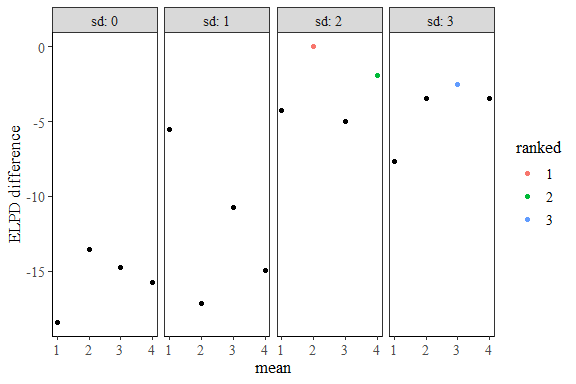

```r
visual_polynomial_selection(different_poly_2PL, perspective = "ELPD", highlightranks = 3)
```

The best model has second-order polynomials for both the mean and the standard deviation, highlighted with red. Further, the resulting plot shows that a second-order polynomial for the standard deviation is clearly needed, as all models with lower polynomial degrees result in lower ELPD values. For the mean a first-order polynomial degree is not sufficient as the ELPD is lower for those when there are high enough polynomials for the standard deviation.

To evaluate the trajectory of the models, the perspective can be set to `"trajacteory"` and the number of visually highlighted best models can be set with `highlightranks`

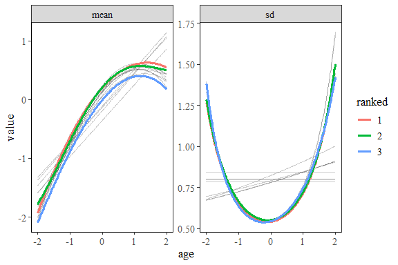

```r
 visual_polynomial_selection(different_poly_2PL, perspective = "trajectory", highlightranks = 3)
```

This supports the choice of the 2PL model with a second-degree polynomial for both the latent trait mean and standard deviation as a good model, and we will select this model for norming the test. The trajectories of all models with a sufficiently high degree to follow the trend look relatively similar.

## Fit best model and extract all important information

Now that the norming model has been selected, it needs to be fitted with a sufficient number of iterations, and all required norming information needs to be extracted. This can be done with the `estimate_norming_model` function.

```r
info <- estimate_norming_model(raw_data = response_data,
                       age_variable = "age",
                       int_variables = 1:50,
                       irt_model  = "2PLnorm",
                       age_model = "poly",
                       poly_mean = 2,
                       poly_sd = 2,
                       seed = 1234,
                       iter_warmup = 2000,
                       iter_sampling =2000,
                       extract_stan_object = TRUE)
```

## Check model convergance

After fitting the IRT-norm model, its fit must be evaluated to judge whether the resulting model is trustworthy. The `IRTnorm` package offers multiple functions to visualize and assess model fit from different perspectives.

A first step in evaluating a Bayesian IRT-norm model is to check whether the MCMC algorithm has converged, as model results are reliable only if convergence is achieved. To check convergence the potential scale reduction factor (Rhat) and the effective sample size (ESS) should be evaluated. Rhat values should be close to 1, and larger ESS values indicate more reliable parameter estimates.

```r
info$conv_info
```

```
#>    diagnostic variable         Min.     1st Qu.       Median         Mean
#> 1        rhat  z_theta    0.9996374    1.000203     1.000467     1.000581
#> 2        rhat p1_theta    1.0003082    1.001447     1.002586     1.004113
#> 3        rhat p2_theta    1.0009391    1.001089     1.001239     1.001391
#> 4        rhat    alpha    0.9997906    1.000115     1.000276     1.000304
#> 5        rhat     beta    1.0010999    1.004169     1.005487     1.005707
#> 6    ess_bulk  z_theta 3131.8409704 9021.383892 10906.571051 10253.393816
#> 7    ess_bulk p1_theta  376.2377060  773.141852  1170.045997   941.949736
#> 8    ess_bulk p2_theta 1347.2019137 1694.745487  2042.289061  1823.622093
#> 9    ess_bulk    alpha 2419.9923977 3419.261574  3786.731622  3870.519362
#> 10   ess_bulk     beta  369.2845934  414.883560   565.895994   710.246625
#> 11   ess_tail  z_theta 4221.9795534 5432.606167  5688.398659  5672.076570
#> 12   ess_tail p1_theta  781.4963566 1433.866779  2086.237202  1714.521959
#> 13   ess_tail p2_theta 3027.1985876 3361.089650  3694.980713  3571.987313
#> 14   ess_tail    alpha 3670.6650071 4574.008001  4863.461958  4860.946769
```

[output cut: 17 more lines]

In this example, Rhat is below 1.01 for all parameter groups, and the effective sample size is above 400 for nearly all parameters, indicating good convergence. The ESS for the tail (`ess_tail`) and bulk (`ess_bulk`) are similar, which is another good sign. A large imbalance between the two indicates sampling issues, in which case the model should be checked further. Possible remedies include increasing `adapt_delta` or adjusting the number of draws via `iter_warmup` and `iter_sampling` when fitting the model.

Additionally, convergence should be inspected visually for key parameters, such as the regression coefficient for the mean (`p1_theta`):

```r
conv_plot <- bayesplot::mcmc_trace(info$model_stan_obj$draws(c("p1_theta")))
#mcmc_trace(mod_poly$draws(c("p2_theta")))
#mcmc_trace(mod_poly$draws(c("alpha")))
#mcmc_trace(mod_poly$draws(c("beta")))
```

```r
data("conv_plot")
conv_plot
```

[output not shown]

If you observe any pattern here, have high values for Rhat or have low effective sample size values, you can try increasing the number of warm up iterations.

## Fit evaluation

For converged models, the next step is to evaluate their fit to the data. A useful indicator of model fit is the comparison between the observed raw score distribution and the posterior predictive (model-implied) raw score distributions obtained from the fitted model. This information can be obtained using the function `NC()` and visualized using the function `NC_visual()`.

This evaluation can be performed either for the entire sample or separately for multiple age groups. Here, we first assess model performance across the entire sample.

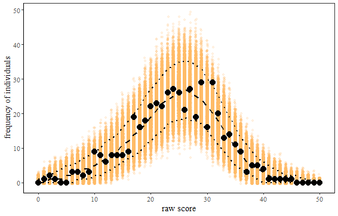

```r
NC_info <- NC(fit_info = info)
NC_visual(NC_info = NC_info)
```

One can see that the observed raw score distribution is plausible under the estimated model. Most observed raw scores (black dots) fall within the 90% interval of the raw score distribution (dotted lines) and all points fall within the possible range indicated by the orange point. This indicated the fitted model reproduces the observed data patterns well.

To check if the model fits well over the entire age range of the tested population, the NC visualization should also be performed separately for different age groups. This can be performed using the same `NC` and `NC_visual` functions by adding the argument `age_range`. This will result in the NC statistics being evaluated based on the groups indicated.

```r
NC_info_age <- NC(fit_info = info,
                      age_range = seq(-2,2,1))
```

[figure not shown]

The model appears to fit well across all age groups, as the observed raw scores are consistent with the distributions implied by the fitted model.

To check more detailed if the observed and model implied properties coincide, the item and person properties can be evaluated. Using the function `item_person_fit()` the observed number of correct item per person /answers per item is plotted against the model implied counts.

First, the fit of items is evaluated.

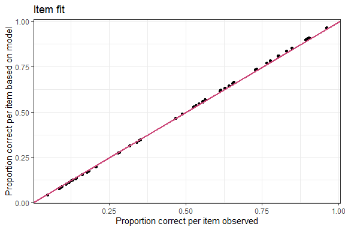

```r
item_person_fit(fit_info =info, parameter = "item")
```

The observed and model-implied frequencies align closely, indicating that the estimated item parameters describe the data accurately.

Next, person-level fit is evaluated.

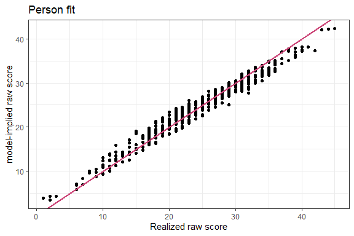

```r
item_person_fit(fit_info =info, parameter = "person")
```

A visual inspection commonly performed when evaluating continuous norming models is a plot of the observed raw sum scores and model-implied quantile curves.

Because IRT models evaluate individuals based on their item response patterns, the raw score does not capture all the information used for norming. In particular, the same raw score can correspond to different latent trait estimates if the item response patterns differ. Although this means that the logic of these plots does not fully align with that of the IRT-based continuous norming models, such a plot can still provide a useful overview of model fit.

The `quantile_curves()` function with `perspective = "rawscore"` visualizes observed raw sum scores across age alongside model-implied quantile curves derived from an age-dependent IRT norming model. Quantile curves are computed from posterior predictive replicated responses and smoothed as a function of age. The plot therefore provides an approximation of the model-implied quantiles corresponding to the observed raw scores.

```r
quantile_curves(fit_info = info, perspective = "rawscore",
                            probs = c(0.05, 0.25, 0.5, 0.75, 0.95))
```

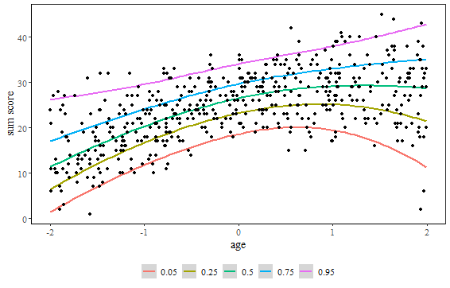

```r
knitr::include_graphics("figures/plot_rawscore.png")
```

In this example, the observed raw score curves align well with the model-implied quantile curves.

A visualization more natural to the interpretation of the norming model can be produced using `quantile_curves` with `perspective = "ability"`. This function plots the estimated latent trait values against the estimated model-implied quantile curves. These quantile curves correspond to the true model-implied curves. Because this plot compares different aspects of the model, it provides insight into the model’s internal consistency and into how the latent trait distribution varies with age. For a well-fitting model, the plot should show no signs of inconsistency. However, the absence of inconsistencies does not, by itself, guarantee good overall model fit.

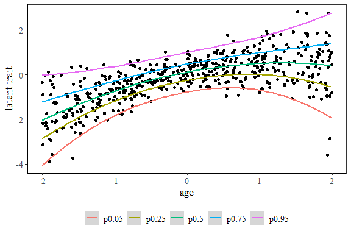

```r
quantile_curves(fit_info = info, perspective = "ability",
                            probs = c(0.05, 0.25, 0.5, 0.75, 0.95))
```

The quantile curves of the latent trait and the estimated latent traits match well, which indicates the model is internally consistent.

Another consistency check is to evaluate the distribution of the normed latent trait within age groups. The model assumes that the normed latent trait is standard normally distributed. To assess whether this assumption holds in the fitted model, the function `normscore_dist()` plots a histogram of the estimated normed latent traits alongside the density of a standard normal distribution per age group.

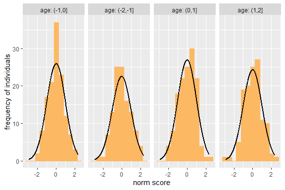

```r
normscore_dist(fit_info= info, age_range = seq(-2,2,1), binwidth = 0.5)
```

In this example the normed latent traits appear normal distributed in all age groups. This further supports the assumption of internal consistency of the model.

An additional check is to evaluate the change of the mean and standard deviation of the latent trait distribution with age. Based on theoretical knowledge the test constructor can evaluate whether the model implied change coincides with theoretical knowledge.

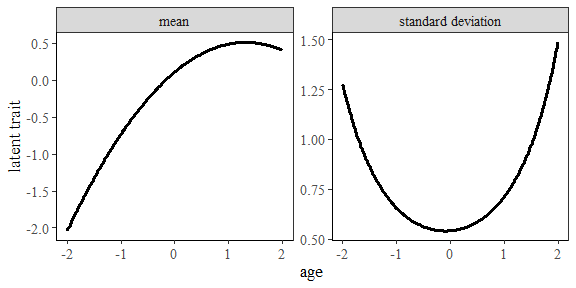

```r
effect_age(fit_info = info)
```

Since these model-implied age effects are relatively close to the age effects in the data-generating mechanism, this plot indicates that the relationship is plausible.

## Norms for a new sample of individuals

The new individual of interest has the response pattern `y`and the age `age`.

```r
y <-  c(1,1,0,0,1,0,1,1,0,0,1,0,0,1,1,0,0,1,1,0,1,1,1,0,1,0,1,1,1,1,1,1,0,0,0,
        1,0,1,1,0,0,0,0,1,1,1,0,1,0,0)
age <- -1
```

To obtain a norm score for this individual, the latent trait estimate is obtained by fitting the IRT-norm model with given item parameter and latent trait distribution draws. The only parameter estimated is the latent trait of the new individual, given all others. The individual’s norm score is the latent trait estimate set in relation to the corresponding latent trait distribution in the reference population. The new data is used only to estimate the individual’s latent trait; the model parameters are not updated and remain fixed at the posterior draws obtained from the original model fit.

```r
info_newperson <- norm_new_individual(new_y = y, new_age= age,
                                     fit_info = info)
# information about the norm score estimate of the individuals norm score
info_newperson$summary
```

```
#> $mean
#> [1] 0.8950466
#>
#> $sd
#> [1] 0.481009
#>
#> $median
#> [1] 0.8902112
#>
#> $ci
#>        2.5%       97.5%
#> -0.03322056  1.84821068
```

Our best estimate of the individuals latent trait is 0.895 which implied the individual is above average. Further, one can say that with 95% certainty the true norm score values lies between -0.033 and 1.848.